# Raport z analizy danych

11 grudzień, 2015

1. Kod wyliczający wykorzystane biblioteki
2. Kod pozwalający wczytać dane z pliku
3. Kod usuwający z danych wiersze posiadające wartość zmiennej res_name równą: “DA”,“DC”,“DT”, “DU”, “DG”, “DI”,“UNK”, “UNX”, “UNL”, “PR”, “PD”, “Y1”, “EU”, “N”, “15P”, “UQ”, “PX4” lub “NAN”
4. Kod pozostawiający tylko unikatowe pary wartości (pdb_code, res_name) + dodatkowe zestawy danych do dalszych zadań
5. Krótkie podsumowanie wartości w każdej kolumnie
6. Sekcja sprawdzającą korelacje między zmiennymi
7. Określenie ile przykładów ma każda z klas (res_name)
8. Wykresy rozkładów liczby atomów (local_res_atom_non_h_count) i elektronów (local_res_atom_non_h_electron_sum)
9. Próba odtworzenia wykresu (oś X - liczba elektronów, oś y - liczba atomów)
10. Tabela pokazującą 10 klas z największą niezgodnością liczby atomów (local_res_atom_non_h_count vs dict_atom_non_h_count) i tabelę pokazującą 10 klas z największą niezgodnością liczby elektronów (local_res_atom_non_h_electron_sum vs dict_atom_non_h_electron_sum;)
11. Sekcja pokazującą rozkład wartości wszystkich kolumn zaczynających się od part_01 z zaznaczeniem (graficznym i liczbowym) średniej wartości;
12. Sekcja sprawdzającą czy na podstawie wartości innych kolumn można przewidzieć liczbę elektronów i atomów oraz z jaką dokładnością można dokonać takiej predykcji; trafność regresji powinna zostać oszacowana na podstawie miar R^2 i RMSE;
13. Sekcja próbującą stworzyć klasyfikator przewidujący wartość atrybutu res_name (w tej sekcji należy wykorzystać wiedzę z pozostałych punktów oraz wykonać dodatkowe czynności, które mogą poprawić trafność klasyfikacji); trafność klasyfikacji powinna zostać oszacowana na danych inne niż uczące za pomocą mechanizmu (stratyfikowanej!) oceny krzyżowej lub (stratyfikowanego!) zbioru testowego.

# Kod wyliczający wykorzystane biblioteki;

```r
library(knitr)
library(dplyr)
library(ggplot2)
library(ggExtra)
library(gridExtra)
library(lattice)
library(corrplot)
library(caret)
```

# Kod pozwalający wczytać dane z pliku;

```r
data <- read.csv("all_summary.txt", sep =";", header = TRUE)
```

# Kod usuwający z danych wiersze posiadające wartość zmiennej res_name równą: “DA”,“DC”,“DT”, “DU”, “DG”, “DI”,“UNK”, “UNX”, “UNL”, “PR”, “PD”, “Y1”, “EU”, “N”, “15P”, “UQ”, “PX4” lub “NAN”;

```r
data <- data %>%
  group_by(res_name) %>%
  filter( !grepl("DA|DI|DC|DT|DU|DG|UNK|UNX|UNL|PR|PD|Y1|EU|N|15P|UQ|PX4|NAN",res_name))
```

# Kod pozostawiający tylko unikatowe pary wartości (pdb_code, res_name) + dodatkowe zestawy danych do dalszych zadań

```r
data <- data[!duplicated(data[c("pdb_code", "res_name")]),]
nopart_data <- select (data, -starts_with("part"))
part1_data <- select (data, starts_with("part_01"))
part1_data[is.na(part1_data)] <- 0
```

# Krótkie podsumowanie wartości w każdej kolumnie;

[output not shown]

# Sekcje sprawdzającą korelacje między zmiennymi;

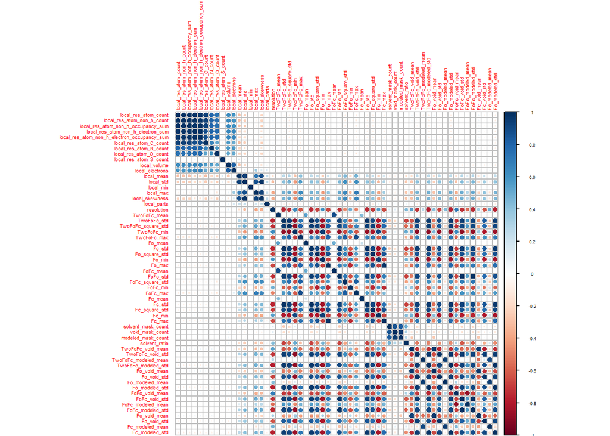

# Określenie ile przykładów ma każda z klas (res_name);

[output not shown]

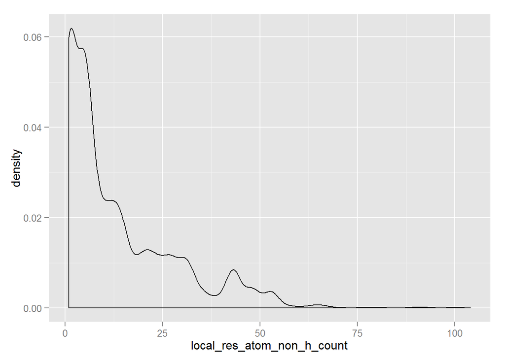

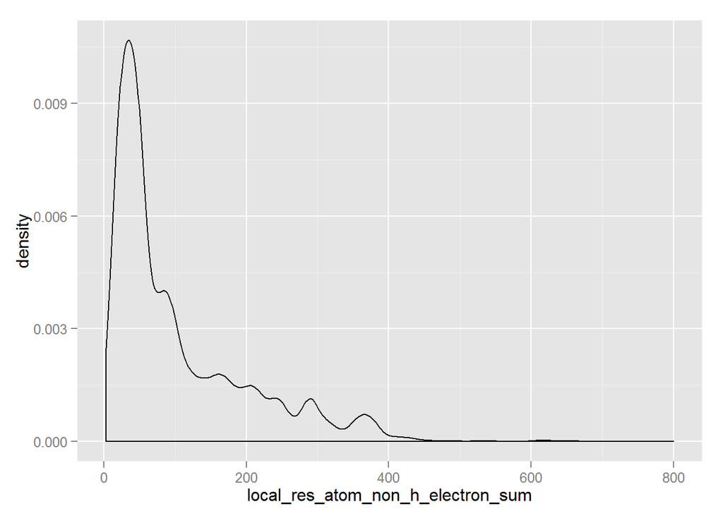

# Próba odtworzenia wykresu (oś X - liczba elektronów, oś y - liczba atomów):

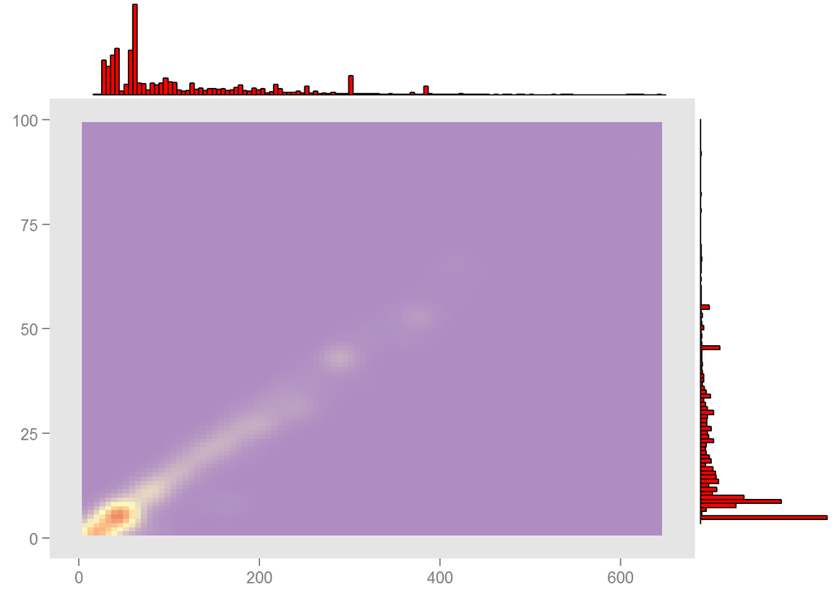

# Tabelę pokazującą 10 klas z największą niezgodnością liczby atomów (local_res_atom_non_h_count vs dict_atom_non_h_count) i tabelę pokazującą 10 klas z największą niezgodnością liczby elektronów (local_res_atom_non_h_electron_sum vs dict_atom_non_h_electron_sum;)

| res_name | pdb_code | local_res_atom_non_h_count | dict_atom_non_h_count | niezgodnosc1 |
| --- | --- | --- | --- | --- |
| PEU | 3n7h | 14 | 83 | 69 |
| PEU | 2wy3 | 19 | 83 | 64 |
| CDL | 3h1h | 40 | 100 | 60 |
| CDL | 3h1j | 50 | 100 | 50 |
| CDL | 2c3e | 55 | 100 | 45 |
| PC1 | 4xdk | 11 | 54 | 43 |
| PC1 | 3b8e | 12 | 54 | 42 |
| CPQ | 3vai | 27 | 60 | 33 |
| PEE | 1xio | 18 | 51 | 33 |
| VV7 | 4uw6 | 95 | 128 | 33 |

[output not shown]

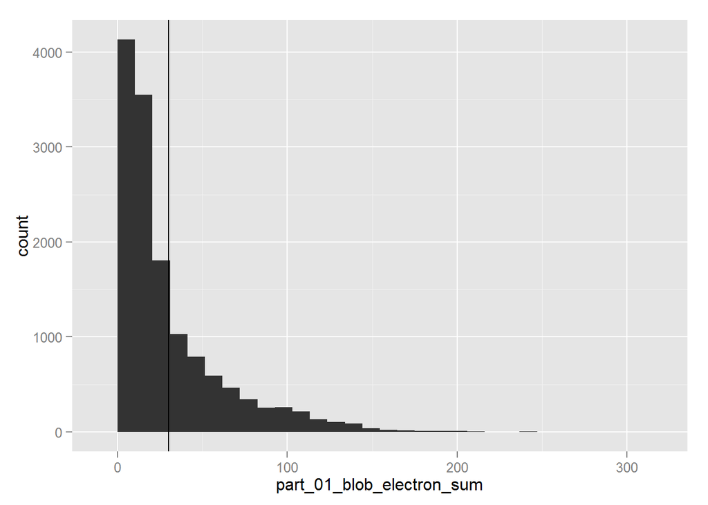

```
## part_01_blob_electron_sum
##                  30.13452
```

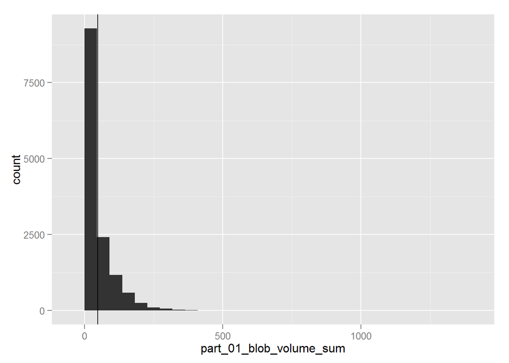

```
## part_01_blob_volume_sum
##                47.22785
```

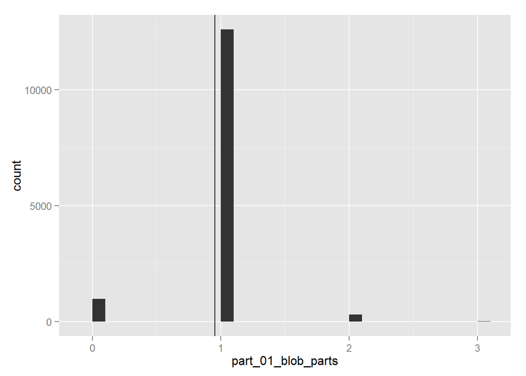

```
## part_01_blob_parts
##          0.9542248
```

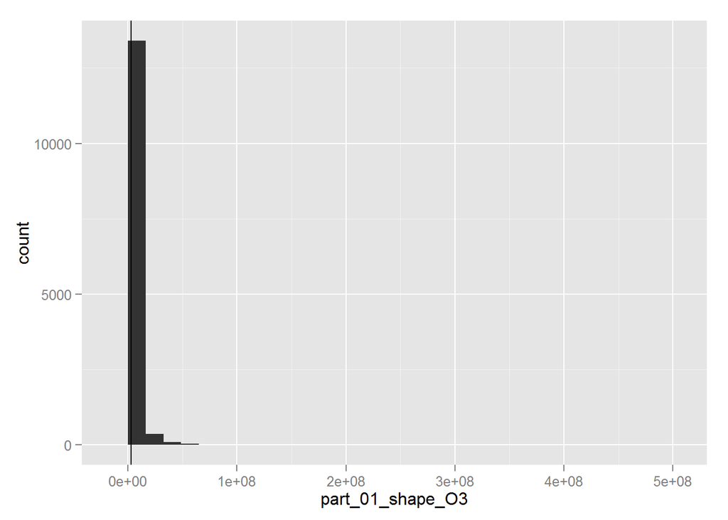

```
## part_01_shape_O3
##          2729331
```

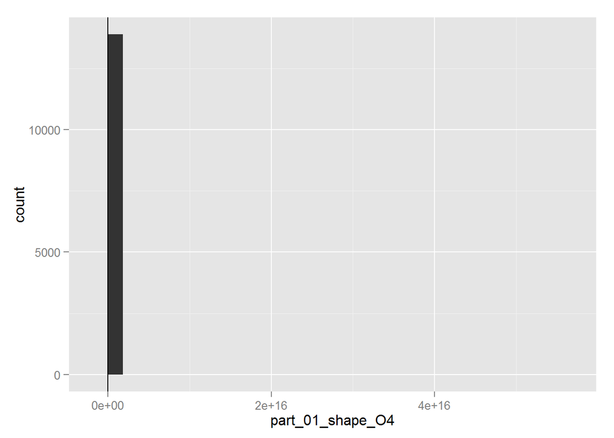

```
## part_01_shape_O4
##     1.306641e+13
```

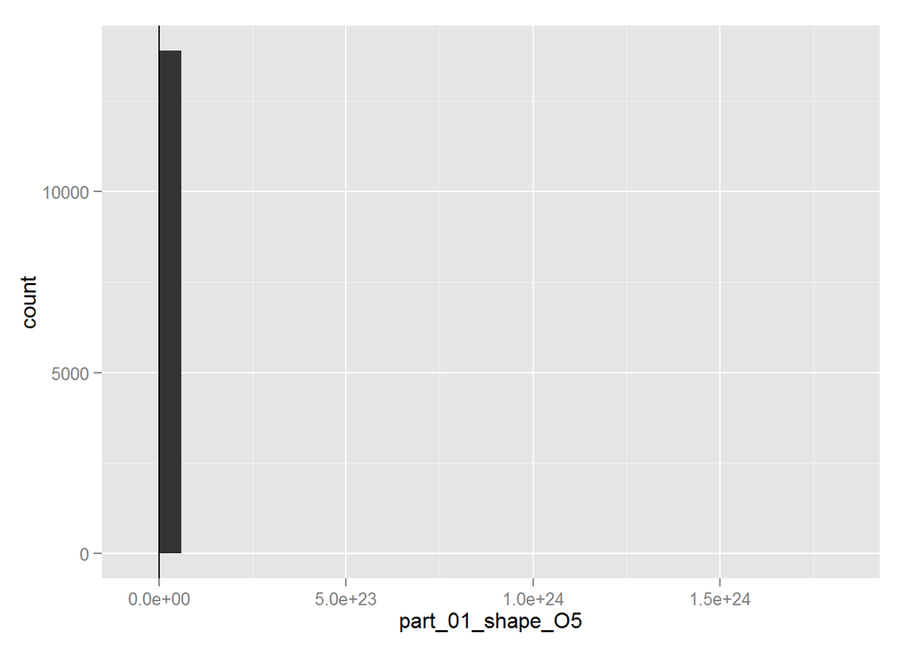

```
## part_01_shape_O5
##     1.470784e+20
```

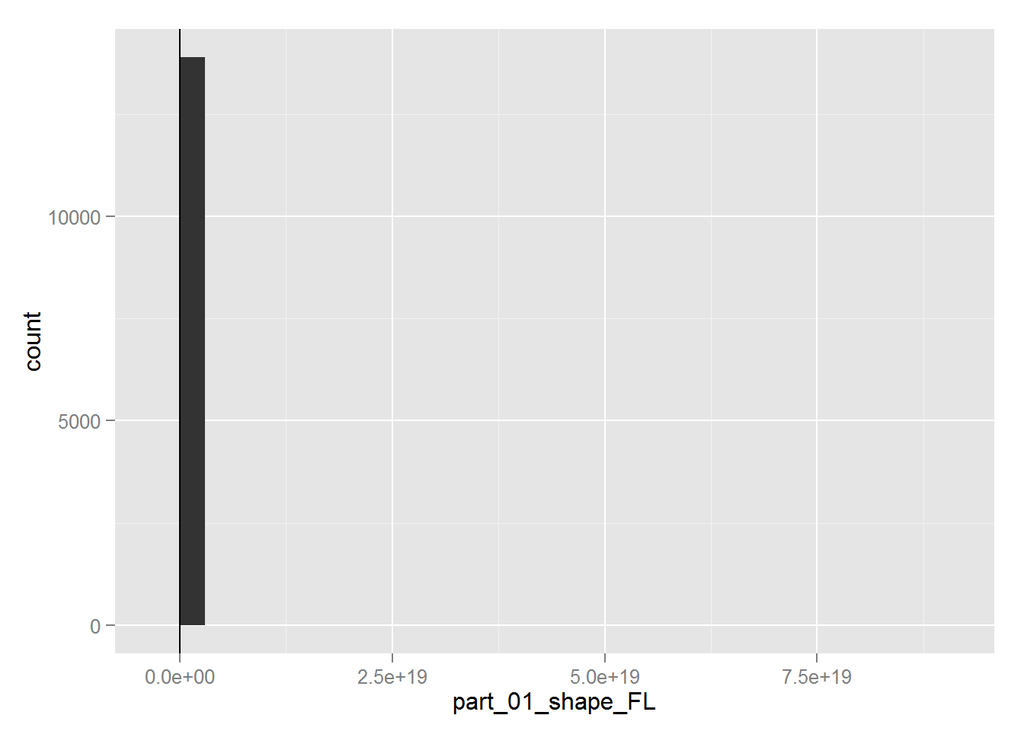

```
## part_01_shape_FL
##     1.726552e+16
```

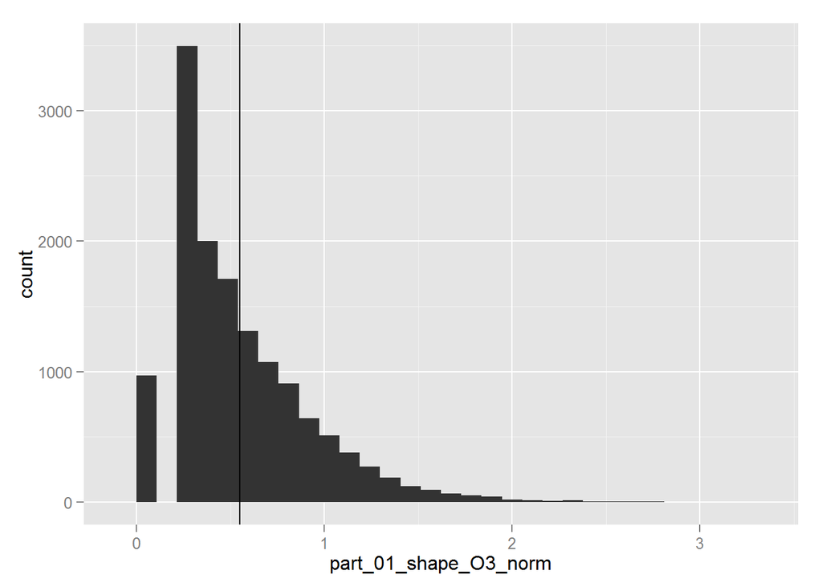

```
## part_01_shape_O3_norm
##             0.5513879
```

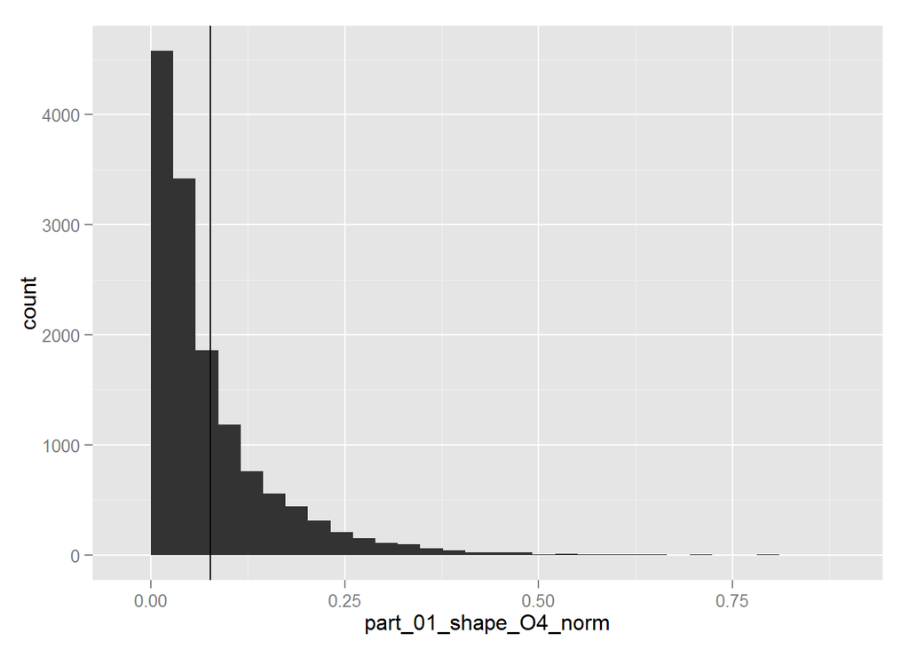

```
## part_01_shape_O4_norm
##            0.07707825
```

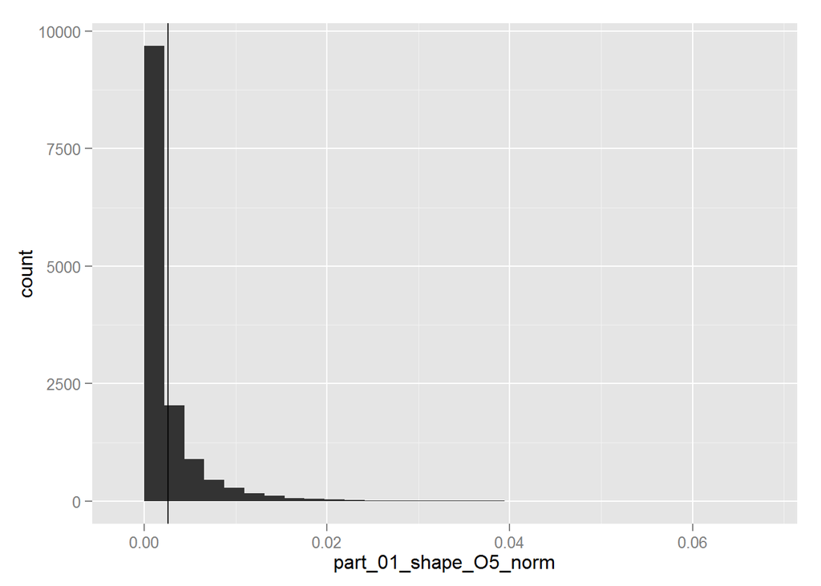

```
## part_01_shape_O5_norm
##           0.002584055
```

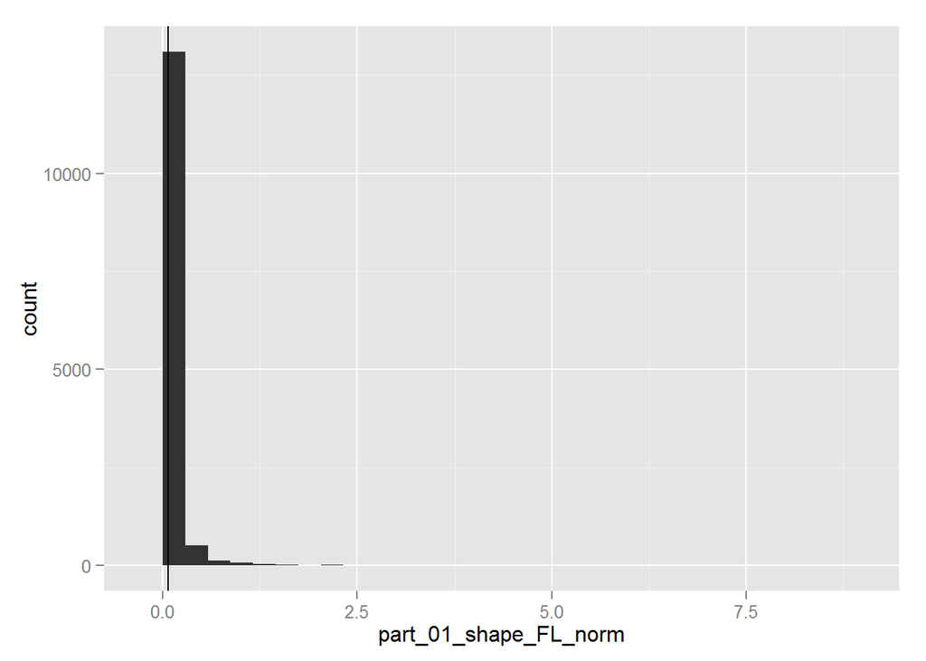

```
## part_01_shape_FL_norm
##            0.07107235
```

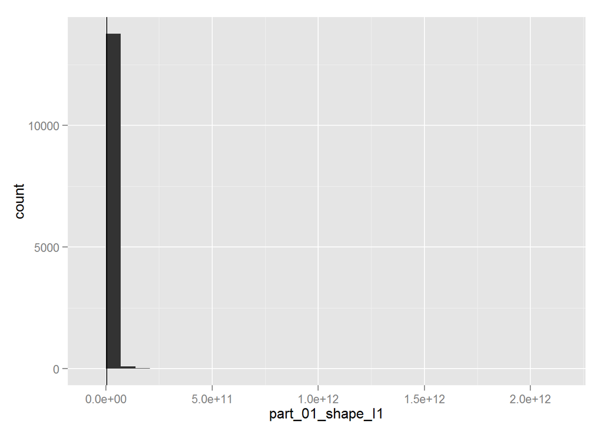

```
## part_01_shape_I1
##       3528621891
```

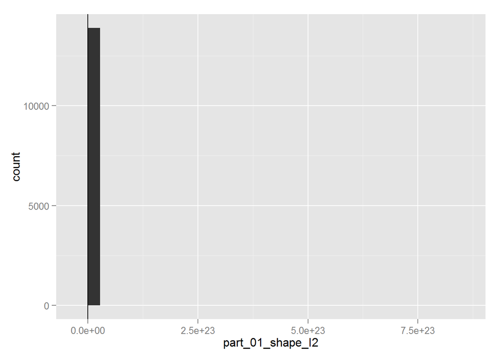

```
## part_01_shape_I2
##     9.121032e+19
```

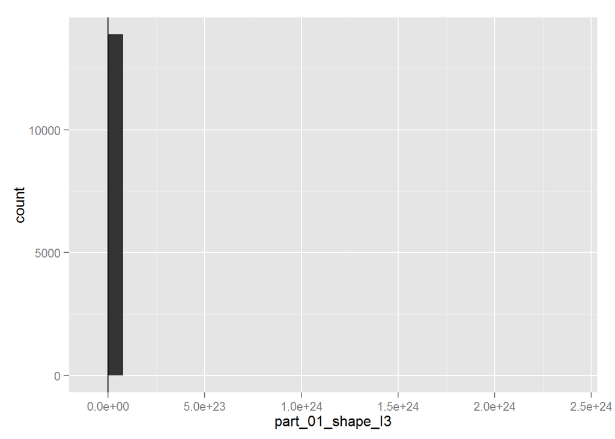

```
## part_01_shape_I3
##     5.037324e+20
```

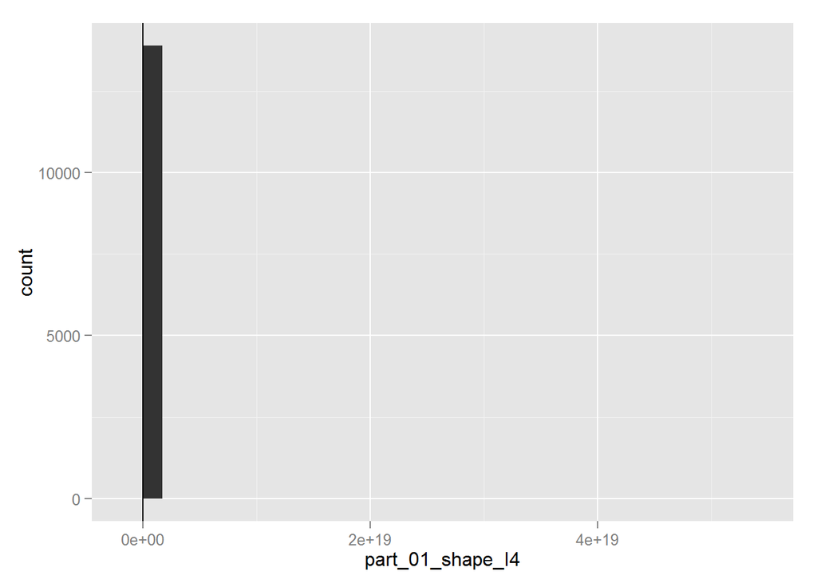

```
## part_01_shape_I4
##     1.032386e+16
```

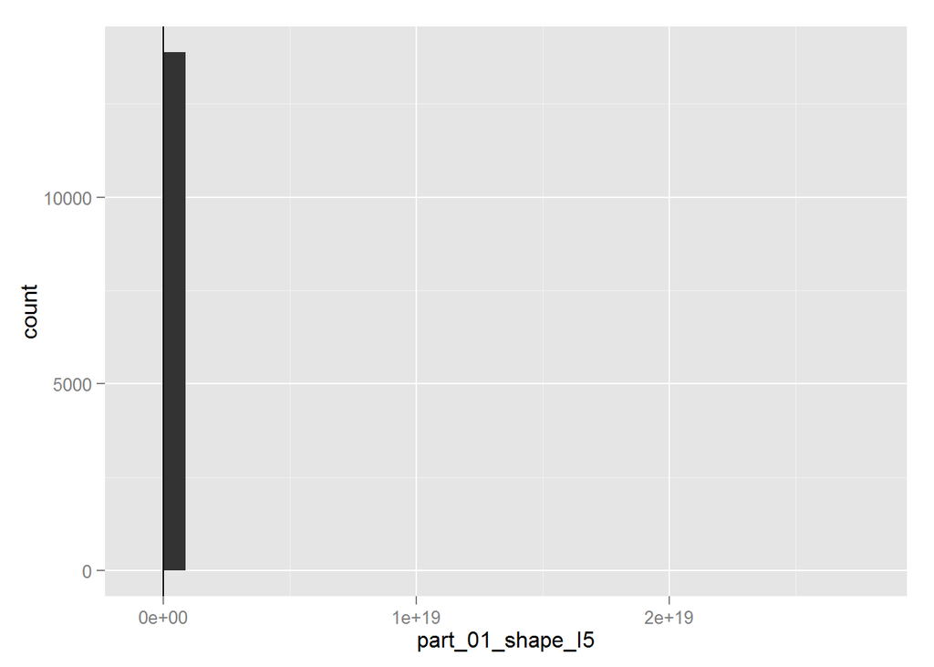

```
## part_01_shape_I5
##     5.696083e+15
```

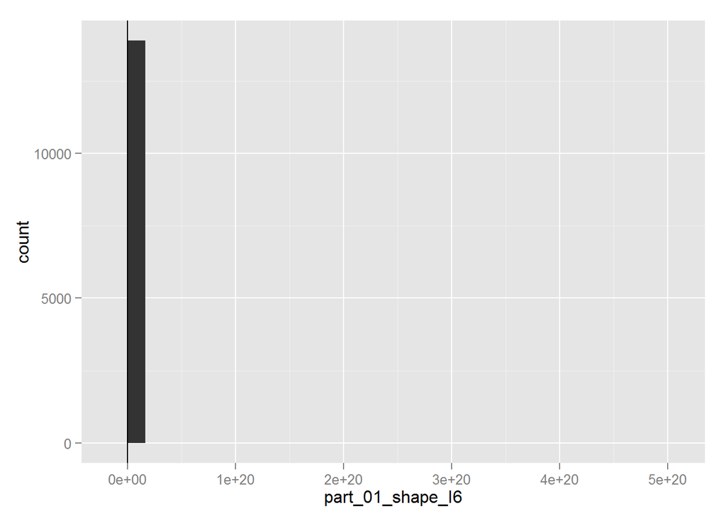

```
## part_01_shape_I6
##     1.271898e+17
```

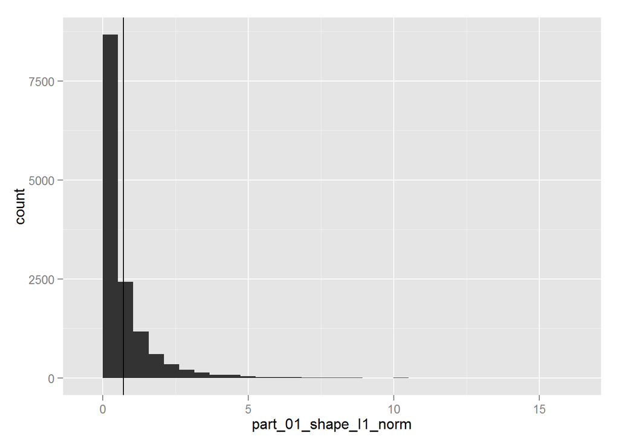

```
## part_01_shape_I1_norm
##             0.7024009
```

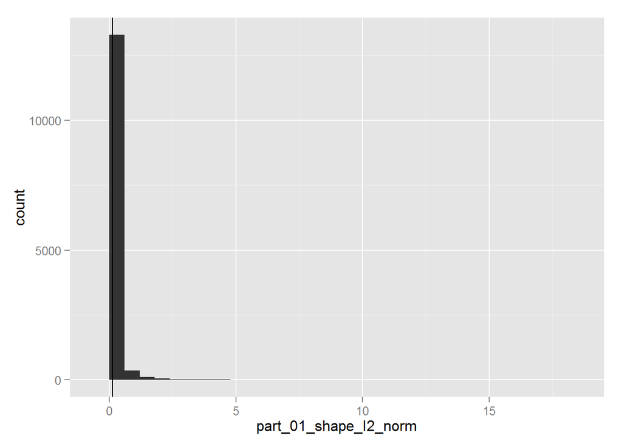

```
## part_01_shape_I2_norm
##             0.1272025
```

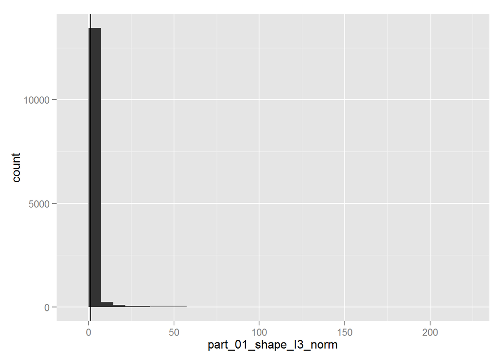

```
## part_01_shape_I3_norm
##              1.157397
```

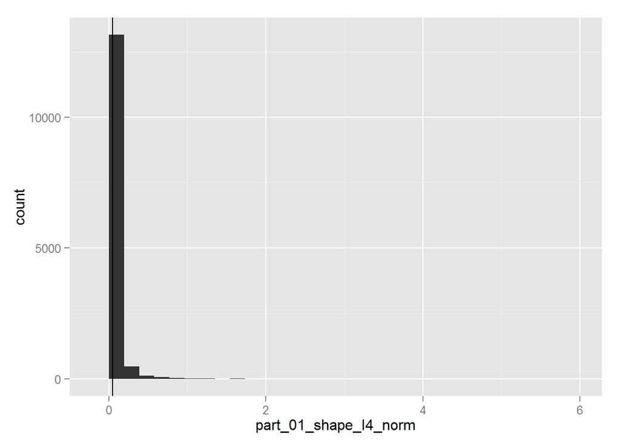

```
## part_01_shape_I4_norm
##            0.04619458
```

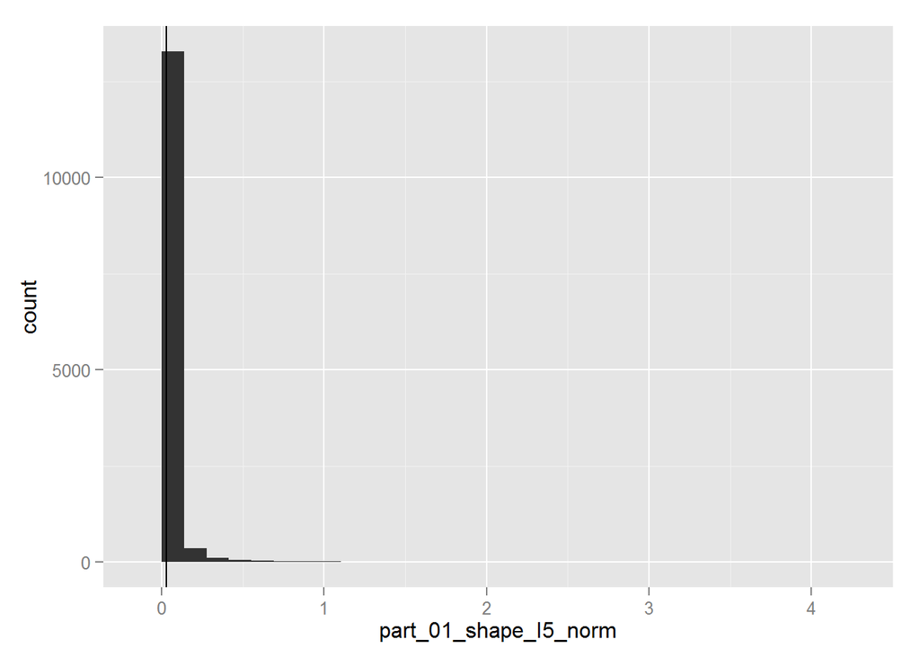

```
## part_01_shape_I5_norm
##             0.0296094
```

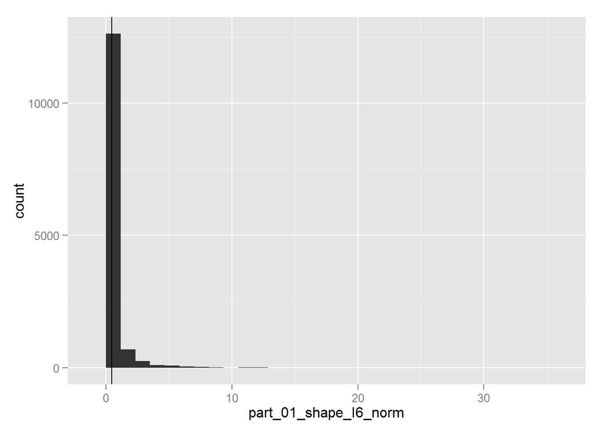

```
## part_01_shape_I6_norm
##             0.4620869
```

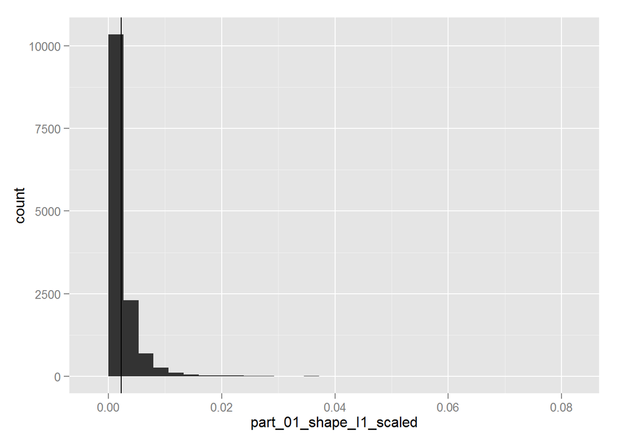

```
## part_01_shape_I1_scaled
##             0.002262881
```

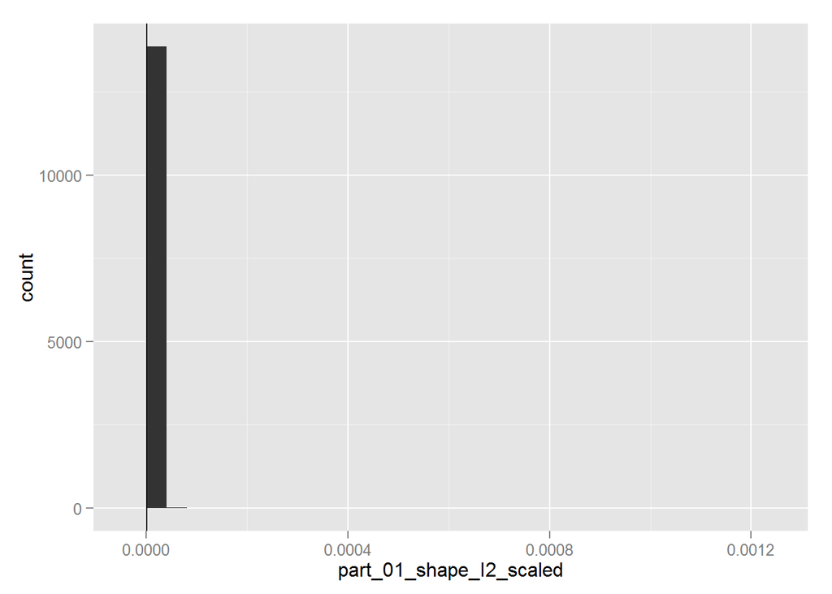